# Applied machine learning - tidymodels

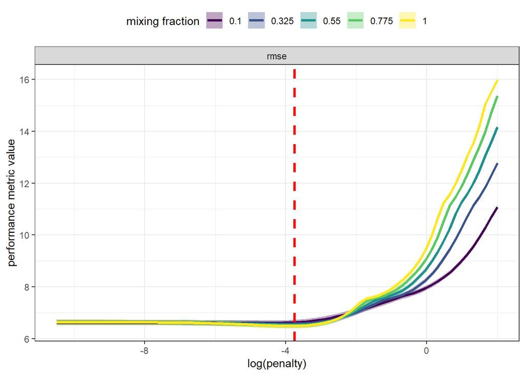

```r
enet_res %>% collect_metrics() %>%
  filter(.metric %in% c("rmse")) %>%
  ggplot(mapping = aes(x = log(penalty))) +
  geom_ribbon(mapping = aes(ymin = mean - std_err,
                            ymax = mean + std_err,
                            group = interaction(mixture, .metric),
                            fill = as.factor(mixture)),
              alpha = 0.35) +
  geom_line(mapping = aes(y = mean,
                          group = interaction(mixture, .metric),
                          color = as.factor(mixture)),
            size = 1.15) +
  geom_vline(data = enet_res %>% select_best("rmse"),
             mapping = aes(xintercept = log(penalty)),
             color = 'red', linetype = 'dashed', size = 1.2) +
  facet_wrap(~.metric, scales = "free_y", ncol = 1) +
  scale_fill_viridis_d("mixing fraction") +
  scale_color_viridis_d("mixing fraction") +
  labs(y = 'performance metric value') +
  theme_bw() +
  theme(legend.position = "top")
```

However, we could also identify the tuning parameters that are “within the margin of error” of the absolute best performance. This concept is known as the “1-standard error rule”. The idea is we prefer simpler models, over more complicated models as one final safe-guard against overfitting. In the context of regularized regression, larger penalty values force more terms to zero and thus create simpler models! Thus, we would like a simpler model that has an average performance metric within 1-standard error of the best average performance metric value.

```r
enet_res %>% select_by_one_std_err(desc(penalty), desc(mixture), metric = 'rmse')
```

```
## # A tibble: 1 x 10
##   penalty mixture .metric .estimator  mean     n std_err .config    .best .bound
##     <dbl>   <dbl> <chr>   <chr>      <dbl> <int>   <dbl> <chr>      <dbl>  <dbl>
## 1  0.0465       1 rmse    standard    6.57    25   0.105 Preproces~  6.49   6.60
```

The 1-standard error rule identified penalty value is represented in the figure below as the orange dashed vertical line.

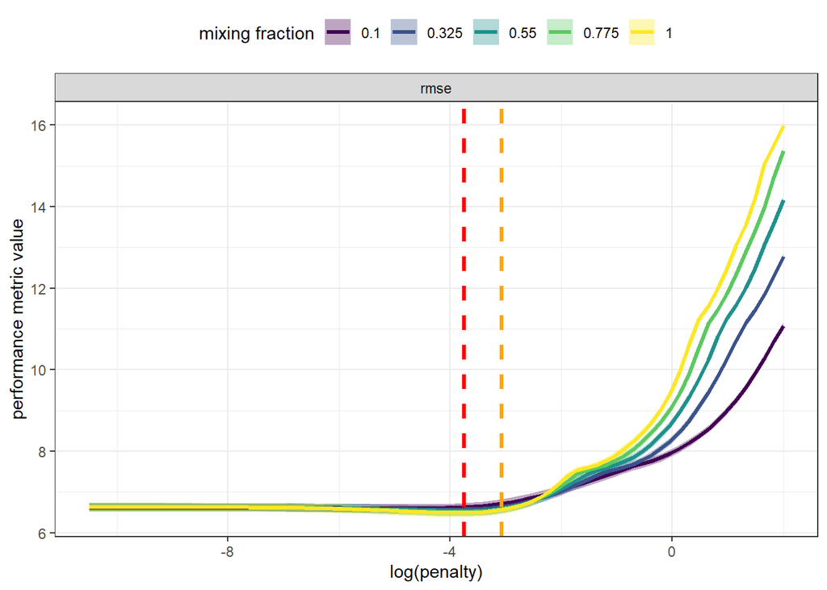

```r
enet_res %>% collect_metrics() %>%
  filter(.metric %in% c("rmse")) %>%
  ggplot(mapping = aes(x = log(penalty))) +
  geom_ribbon(mapping = aes(ymin = mean - std_err,
                            ymax = mean + std_err,
                            group = interaction(mixture, .metric),
                            fill = as.factor(mixture)),
              alpha = 0.35) +
  geom_line(mapping = aes(y = mean,
                          group = interaction(mixture, .metric),
                          color = as.factor(mixture)),
            size = 1.15) +
  geom_vline(data = enet_res %>% select_best("rmse"),
             mapping = aes(xintercept = log(penalty)),
             color = 'red', linetype = 'dashed', size = 1.2) +
  geom_vline(data = enet_res %>%
               select_by_one_std_err(desc(penalty), desc(mixture), metric = 'rmse'),
             mapping = aes(xintercept = log(penalty)),
             color = 'orange', linetype = 'dashed', size = 1.2) +
  facet_wrap(~.metric, scales = "free_y", ncol = 1) +
  scale_fill_viridis_d("mixing fraction") +
  scale_color_viridis_d("mixing fraction") +
  labs(y = 'performance metric value') +
  theme_bw() +
  theme(legend.position = "top")
```

Let’s zoom in so it’s easier to see the difference in the performance between the best penalty and that identified by the one standard error rule. Since both sets of parameters correspond to a mixing fraction of 1, all other mixing fraction values have been removed to simplify the figure. Also, the ribbon has been exchanged with the line range (error bar) in the figure below. The horizontal grey line corresponds to the average RMSE plus one standard error for the tuning parameter with the lowest average RMSE. Notice that the penalty value identified as the one standard error rule recommended value is the “last” marker less than the grey dashed horizontal line. This is what we mean when we say the one standard error rule tuning set gives performance within the margin of error of the best set.

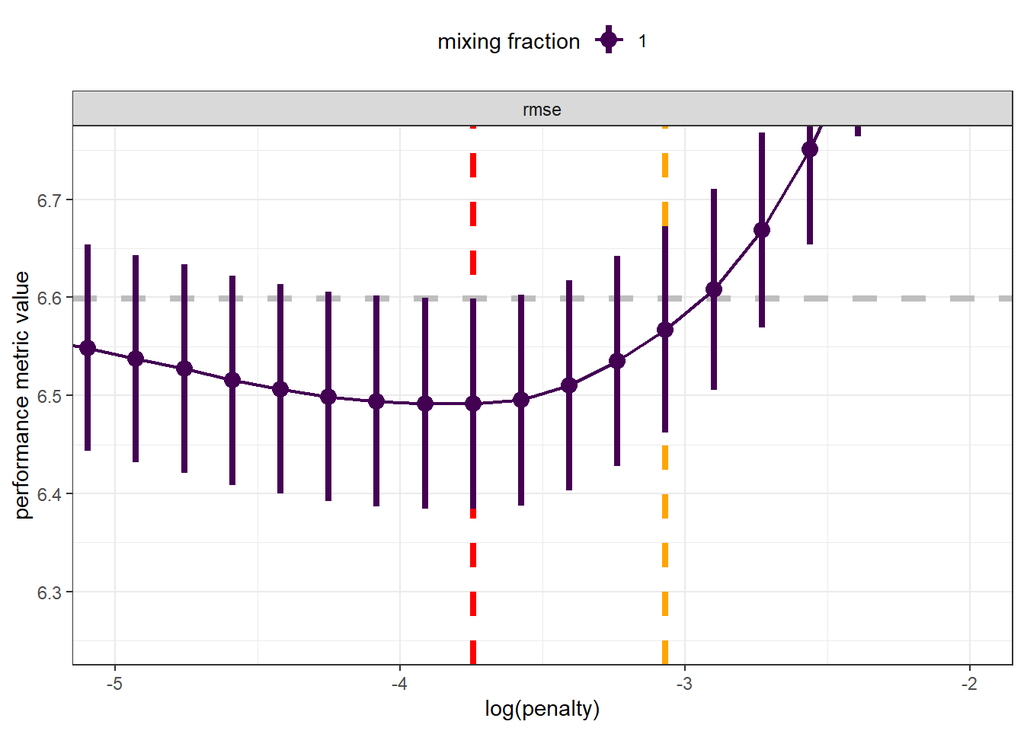

```r
enet_res %>% collect_metrics() %>%
  filter(.metric %in% c("rmse")) %>%
  filter(mixture == 1) %>%
  ggplot(mapping = aes(x = log(penalty))) +
  geom_vline(data = enet_res %>% select_best("rmse"),
             mapping = aes(xintercept = log(penalty)),
             color = 'red', linetype = 'dashed', size = 1.55) +
  geom_vline(data = enet_res %>%
               select_by_one_std_err(desc(penalty), desc(mixture), metric = 'rmse'),
             mapping = aes(xintercept = log(penalty)),
             color = 'orange', linetype = 'dashed', size = 1.55) +
  geom_hline(data = enet_res %>%
               show_best('rmse', n = 1),
             mapping = aes(yintercept = mean + std_err),
             color = 'grey', size = 1.55, linetype = 'dashed') +
  geom_linerange(mapping = aes(ymin = mean - std_err,
                               ymax = mean + std_err,
                               group = interaction(mixture, .metric),
                               color = as.factor(mixture)),
                 size = 1.55) +
  geom_line(mapping = aes(y = mean,
                          group = interaction(mixture, .metric),
                          color = as.factor(mixture)),
            size = 0.75) +
  geom_point(mapping = aes(y = mean,
                           color = as.factor(mixture)),
             size = 3.55) +
  coord_cartesian(ylim = c(6.25, 6.75), xlim = c(-5, -2)) +
  facet_wrap(~.metric, scales = "free_y", ncol = 1) +
  scale_fill_viridis_d("mixing fraction") +
  scale_color_viridis_d("mixing fraction") +
  labs(y = 'performance metric value') +
  theme_bw() +
  theme(legend.position = "top")
```

Let’s finalize the elastic net model by fitting it one last time on the complete training set with the one standard error rule identified tuning parameters.

```r
enet_lowest_rmse_params <- enet_res %>%
  select_by_one_std_err(desc(penalty), desc(mixture), metric = 'rmse') %>%
  select(all_of(names(enet_grid)))

final_enet_wflow <- enet_wflow %>%
  finalize_workflow(enet_lowest_rmse_params)

final_enet_fit <- final_enet_wflow %>% fit(my_concrete)
```

How many coefficients have been turned off with our final elastic net model? As shown below 34 features, or about 30% of the features have been turned off. Many of the features are thus required in the cubic RSM to maximize the performance and predictive accuracy of the model.

```r
final_enet_fit %>%
  tidy() %>%
  filter(!stringr::str_detect(term, "Intercept")) %>%
  summarise(num_zero = sum(estimate == 0),
            fraction_zero = mean(estimate == 0))
```

```
## # A tibble: 1 x 2
##   num_zero fraction_zero
##      <int>         <dbl>
## 1       34         0.315
```

Let’s now compare the tuned elastic net summarized results with the other models we trained previously.

```r
all_cv_summaries <- all_cv_summaries %>%
  bind_rows(enet_res %>% collect_metrics(summarize = TRUE) %>%
              inner_join(enet_lowest_rmse_params %>%
                           mutate(keep_these = 'yes'),
                         by = names(enet_lowest_rmse_params)) %>%
              select(-keep_these) %>%
              mutate(wflow_id = "enet"))
```

The cross-validation performance metric summaries for all linear methods are shown below. Notice that the elastic net model’s average RMSE is slightly lower than the original cubic RSM’s average RMSE. As we will learn this semester the original models are fit by maximizing the likelihood and thus correspond to a regularized model with zero penalty. The original cubic RSM keeps all features, and thus slightly overfits relative to the elastic net model which turned off about 30% of the features that are not necessary.

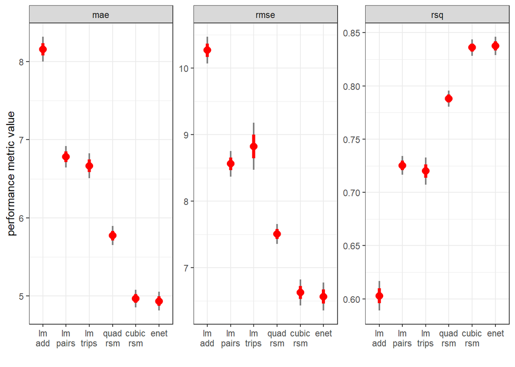

```r
all_cv_summaries %>%
  mutate(wflow_id = stringr::str_replace(wflow_id, " ", "\n")) %>%
  mutate(wflow_id = factor(wflow_id,
                           levels = c("lm\nadd", "lm\npairs", "lm\ntrips",
                                      "quad\nrsm", "cubic\nrsm", "enet"))) %>%
  ggplot(mapping = aes(x = wflow_id)) +
  geom_linerange(mapping = aes(ymin = mean - 2*std_err,
                               ymax = mean + 2*std_err,
                               group = interaction(.metric, wflow_id)),
                 color = 'grey50', size = 0.75) +
  geom_linerange(mapping = aes(ymin = mean - 1*std_err,
                               ymax = mean + 1*std_err,
                               group = interaction(.metric, wflow_id)),
                 color = 'red', size = 1.45) +
  geom_point(mapping = aes(y = mean),
             color = 'red', size = 3.1) +
  facet_wrap(~.metric, scales = "free_y", nrow = 1) +
  labs(x = '', y = 'performance metric value') +
  theme_bw()
```

Let’s also check the correlation structure between the elastic net model and the others we trained previously. The elastic net model is highly correlated with the original cubic RSM. This makes sense since the elastic net model consists of 70% of the same features as the original RSM.

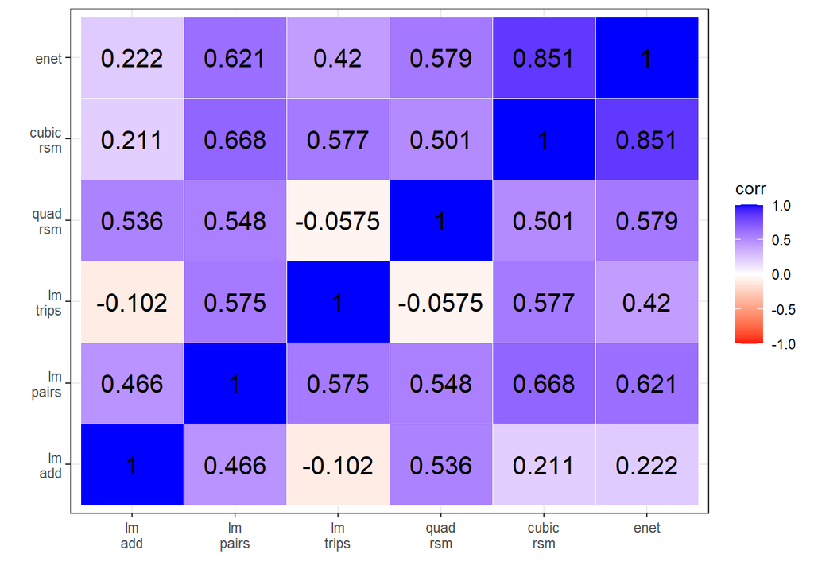

```r
all_cv_results <- all_cv_results %>%
  bind_rows(enet_res %>% collect_metrics(summarize = FALSE) %>%
              inner_join(enet_lowest_rmse_params %>%
                           mutate(keep_these = 'yes'),
                         by = names(enet_lowest_rmse_params)) %>%
              select(-keep_these) %>%
              mutate(wflow_id = "enet"))

all_cv_results %>%
  mutate(wflow_id = stringr::str_replace(wflow_id, " ", "\n")) %>%
  filter(.metric == 'rsq') %>%
  select(wflow_id, .estimate, id, id2) %>%
  pivot_wider(id_cols = c("id", "id2"),
              names_from = 'wflow_id', values_from = '.estimate') %>%
  select(-id, -id2) %>%
  corrr::correlate(quiet = TRUE, diagonal = 1) %>%
  corrr::stretch() %>%
  mutate(x = factor(x,
                    levels = c("lm\nadd", "lm\npairs", "lm\ntrips",
                                      "quad\nrsm", "cubic\nrsm", "enet")),
         y = factor(y,
                    levels = c("lm\nadd", "lm\npairs", "lm\ntrips",
                                      "quad\nrsm", "cubic\nrsm", "enet"))) %>%
  ggplot(mapping = aes(x = x, y = y)) +
  geom_tile(mapping = aes(fill = r),
            color = 'white') +
  geom_text(mapping = aes(label = signif(r, 3)),
            color = 'black', size = 5.5) +
  scale_fill_gradient2('corr',
                       low = 'red', mid = 'white', high = 'blue',
                       midpoint = 0,
                       limits = c(-1, 1)) +
  labs(x='', y='') +
  theme_bw()
```

#### Other features

We will stop here with trying out other formulations or *structured* parametric models. However, think about what features you would want to try on your own! Would you want to include log-transformations of the inputs? What about converting some of the continuous into categorical variables? Try creating other custom recipes to see if you can out perform the models demonstrated here!

### Non-linear methods

Now that we have tried out multiple linear methods, it is time to see if we more advanced non-linear approaches can give us even better results. The methods we will use next are those typically considered when we say “machine learning”. However, it is important to note our linear methods were capable of achieving an R-squared of about 83% on average on new data (as estimated by repeated cross-validation). The linear model commonly thought of with linear additive features was capable of an R-squared of about 60%. We know interactions and non-linearity are important, but we will now see if advanced methods can outperform the parametric expressions.

#### Neural network

We will use a single hidden layer feed forward neural network. `tidymodels` denotes this as the multilayer perceptron (mlp). There are several computational engines available for neural networks, at the moment within `tidymodels`. The `keras` engine is the keras API built on top of TensorFlow, and thus we can train TensorFlow neural networks with `tidymodels` if we would like. This report however will use the `nnet` engine which uses the `nnet` package. Please download and install the `nnet` package if you would like to run this example yourself.

```r
show_engines('mlp')
```

```
## # A tibble: 4 x 2
##   engine mode
##   <chr>  <chr>
## 1 keras  classification
## 2 keras  regression
## 3 nnet   classification
## 4 nnet   regression
```

We will learn about the computational details of neural networks later in the semester. For now, we will focus on that we must specify the number of hidden units (neurons), the regularization (penalty factor), and the number of epochs (the number of iterations to use). All three options can be tuned, but we will simplify the approach for now by fixing the epochs to 2000. In truth, the `nnet` package treats this as the maximum number of iterations and so fewer iterations may be used. We will discuss issues around the number of iterations and epochs later in the semester. The neural network model is specified in the code chunk below.

```r
nnet_spec <- mlp(hidden_units = tune(), penalty = tune(), epochs = 2000) %>%
  set_engine("nnet", MaxNWts = 2500, trace=FALSE) %>%
  set_mode("regression")
```

For reference, the translation to the `nnet` package code is shown below.

```r
nnet_spec %>% translate()
```

```
## Single Layer Neural Network Specification (regression)
##
## Main Arguments:
##   hidden_units = tune()
##   penalty = tune()
##   epochs = 2000
##
## Engine-Specific Arguments:
##   MaxNWts = 2500
##   trace = FALSE
##
## Computational engine: nnet
##
## Model fit template:
## nnet::nnet(formula = missing_arg(), data = missing_arg(), weights = missing_arg(),
##     size = tune(), decay = tune(), maxit = 2000, MaxNWts = 2500,
##     trace = FALSE, linout = TRUE)
```

We will again use a simple grid search to tune the model. The grid will consist of combinations of the number of hidden units and the penalty factor. The default bounds on the number of hidden units are:

```r
hidden_units()
```

```
## # Hidden Units (quantitative)
## Range: [1, 10]
```

Those are useful bounds to start with to help minimize the run time, but let’s allow for more complicated and flexible behavior by allowing up to 30 hidden units. The penalty factor will help regularize the added flexibility. The code chunk below creates the search grid using the `crossing()` from function the `tidyr` package (which is part of the `tidyverse`). As shown by the glimpse below, we will try 105 tuning parameter combinations.

```r
nnet_grid <- crossing(hidden_units = c(5, 10, 15, 25, 30),
                      penalty = 10^(seq(-10, 1.75, length.out = 21)))

nnet_grid %>% glimpse()
```

```
## Rows: 105
## Columns: 2
## $ hidden_units <dbl> 5, 5, 5, 5, 5, 5, 5, 5, 5, 5, 5, 5, 5, 5, 5, 5, 5, 5, 5, ~
## $ penalty      <dbl> 1.000000e-10, 3.868121e-10, 1.496236e-09, 5.787620e-09, 2~
```

The neural network workflow is created in the code chunk below. We do not use the RSM recipes. Instead, we simply use the standardized recipe, `bp_stan`. As we will learn later in the semester, the neural network consists of linear combinations of non-linear transformation of linear combinations of the inputs. We therefore do not need to create interactions or polynomial terms.

```r
nnet_wflow <- workflow() %>%
  add_model(nnet_spec) %>%
  add_recipe(bp_stan)
```

The neural network is trained and assessed in the code chunk below. The random seed is set to help control the initialization of the neural network weights and biases. Please be advised this may take awhile to complete, especially if you cannot run in parallel.

```r
start_nnet <- Sys.time()

set.seed(111)
nnet_res <- tune_grid(
  nnet_wflow,
  resamples = cv_folds,
  grid = nnet_grid,
  metrics = my_metrics
)

finish_nnet <- Sys.time()

finish_nnet - start_nnet
```

```
## Time difference of 13.16683 mins
```

Let’s now examine the neural network performance for the different number of hidden units and penalty values.

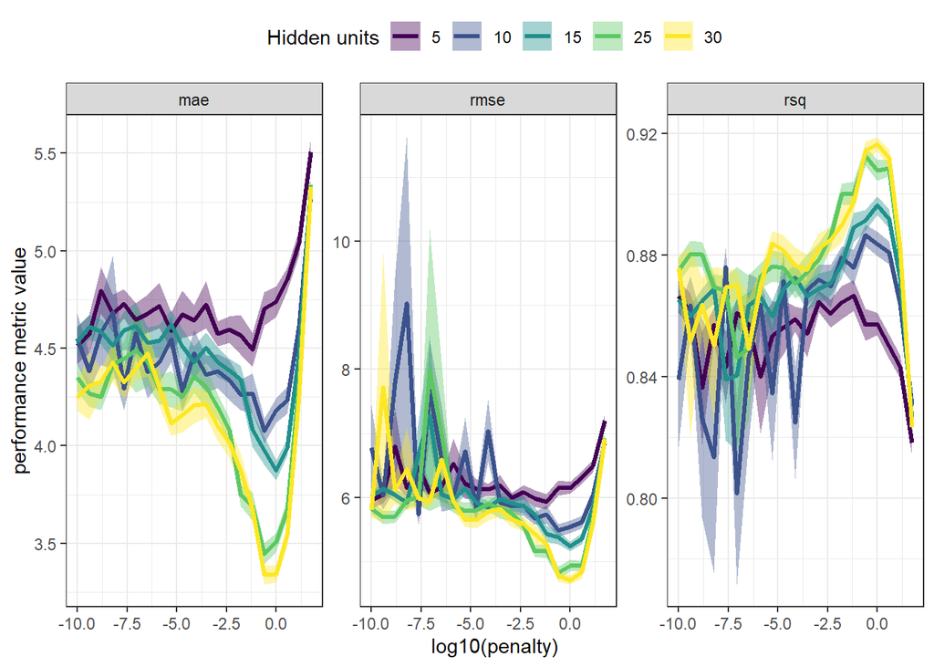

```r
nnet_res %>% collect_metrics() %>%
  ggplot(mapping = aes(x = log10(penalty))) +
  geom_ribbon(mapping = aes(group = interaction(hidden_units, .metric),
                            fill = as.factor(hidden_units),
                            ymin = mean - std_err,
                            ymax = mean + std_err),
              alpha = 0.4) +
  geom_line(mapping = aes(group = interaction(hidden_units, .metric),
                          color = as.factor(hidden_units),
                          y = mean),
            size = 1.2) +
  facet_wrap(~.metric, scales = "free_y", nrow = 1) +
  scale_fill_viridis_d("Hidden units") +
  scale_color_viridis_d("Hidden units") +
  labs(y = 'performance metric value') +
  theme_bw() +
  theme(legend.position = "top")
```

The neural network with 10 hidden units certainly acts strangely in terms of RMSE. Notice that the MAE behavior appears more “stable”, which is consistent with the MAE being less sensitive to extreme values. The penalty term serves a similar role to that described with elastic net, since it is trying to restrict complexity. We will focus on how the penalty term accomplishes that later in the semester. What you should focus on at the moment is how the performance metric changes as the penalty changes. For example, with 30 hidden units the performance is “bouncing around” until a `log10(penalty)` value of -5. Then the performance improves as the penalty increases, before achieving peak performance near the penalty value of 1 (log10(0)=1). Increasing the penalty further causes the performance to get worse, as shown by the MAE increasing rapidly for log10(penalty)>0. The penalty controls complexity, low values represent greater complexity and large values represent simplicity. The above figure illustrates that overly complex models can overfit, while overly simple models can *underfit*. We wish to strike a balance and find the most flexible yet simple model that **generalizes** to new data. This concept, also referred to as the **bias-variance trade-off**, exists for all types of models. For this application, the neural network tuning behavior perfectly illustrated the concept. We will discuss this idea many times throughout the semester.

Let’s go ahead and identify the tuning parameters that minimize the resampling averaged RMSE. We could make use of the one standard error rule again, but we will select the best overall performance for simplicity with the neural network. The neural network workflow is “finalized” with those selected tuning parameters.

```r
nnet_lowest_rmse_params <- nnet_res %>% select_best('rmse')

final_nnet_wflow <- nnet_wflow %>%
  finalize_workflow(nnet_lowest_rmse_params)
```

Let’s fit the neural network one last time with the entire training set and the selected tuning parameters.

```r
final_nnet_fit <- final_nnet_wflow %>% fit(my_concrete)
```

We will hold off directly comparing the neural network performance to the previous set of models until we have finished training and tuning the remaining models. However, let’s add the neural network’s performance to our cross-validation results.

```r
all_cv_summaries <- all_cv_summaries %>%
  bind_rows(nnet_res %>% collect_metrics(summarize = TRUE) %>%
              inner_join(nnet_lowest_rmse_params %>%
                           mutate(keep_these = 'yes'),
                         by = names(nnet_lowest_rmse_params)) %>%
              select(-keep_these) %>%
              mutate(wflow_id = "nnet"))

all_cv_results <- all_cv_results %>%
  bind_rows(nnet_res %>% collect_metrics(summarize = FALSE) %>%
              inner_join(nnet_lowest_rmse_params %>%
                           mutate(keep_these = 'yes'),
                         by = names(nnet_lowest_rmse_params)) %>%
              select(-keep_these) %>%
              mutate(wflow_id = "nnet"))
```

#### Support Vector Machine (SVM)

The SVM can be viewed as an entire modeling framework, rather than a single type of model. In layman’s terms, the beauty of the SVM lies with the fact that the user is free to select a **kernel** to represent similarity. The kernel can be linear, highly non-linear, focus on smooth behavior, or handle jumps and discontinuous behavior. The user is free to choose and compare different kernels to identify the best model. Two popular kernels are the polynomial kernel and the radial basis function (RBF) (also referred to as a Gaussian kernel). We will focus here just on the RBF.

The SVM RBF has three tuning parameters, the “sigma”, the “cost”, and the “margin” (usually referred to as epsilon in the SVM literature). To get a sense for the scale of the “sigma” parameter let’s go ahead and fit a SVM RBF using the entire training set and representative values for the cost and margin parameters. It is important to use standardized inputs with SVM RBF, and so the `bp_stan` recipe object is used within the workflow definition. We are using the `kernlab` package as the engine, so please download and install `kernlab` to run the code chunk below.

```r
rbf_default <- svm_rbf(cost = 1, margin = 1) %>%
  set_engine('kernlab') %>%
  set_mode('regression')

rbf_default_wflow <- workflow() %>%
  add_model(rbf_default) %>%
  add_recipe(bp_stan)

rbf_default_fit <- rbf_default_wflow %>% fit(my_concrete)

rbf_default_fit
```

```
## == Workflow [trained] ==========================================================
## Preprocessor: Recipe
## Model: svm_rbf()
##
## -- Preprocessor ----------------------------------------------------------------
## 2 Recipe Steps
##
## * step_center()
## * step_scale()
##
## -- Model -----------------------------------------------------------------------
## Support Vector Machine object of class "ksvm"
##
## SV type: eps-svr  (regression)
##  parameter : epsilon = 1  cost C = 1
##
## Gaussian Radial Basis kernel function.
##  Hyperparameter : sigma =  0.128980844327554
##
## Number of Support Vectors : 65
##
## Objective Function Value : -16.2059
## Training error : 0.314435
```

The estimated “sigma” parameter is displayed above. We are **not** using that single value for the fit, since it was estimated using the entire data set. Instead, we are using that value to help set representative bounds on the parameter. We will again use resampling and a search grid to tune the parameters. We will not get into the details of the interpretation of the tuning parameters in this report. The SVM RBF search grid is created in the code chunk below.

```r
rbf_grid <- crossing(rbf_sigma = c(0.01, 0.05, 0.1, 0.2, 0.4, 0.8, 1.25, 1.5),
                     cost = c(0.01, 0.1, 1, 10, 100, 1000),
                     margin = c(0.01, 0.05, 0.1, 1.0))

rbf_grid %>% glimpse()
```

```
## Rows: 192
## Columns: 3
## $ rbf_sigma <dbl> 0.01, 0.01, 0.01, 0.01, 0.01, 0.01, 0.01, 0.01, 0.01, 0.01, ~
## $ cost      <dbl> 1e-02, 1e-02, 1e-02, 1e-02, 1e-01, 1e-01, 1e-01, 1e-01, 1e+0~
## $ margin    <dbl> 0.01, 0.05, 0.10, 1.00, 0.01, 0.05, 0.10, 1.00, 0.01, 0.05, ~
```

The SVM specification and workflow are defined below.

```r
svm_rbf_spec <- svm_rbf(cost = tune(), rbf_sigma = tune(), margin = tune()) %>%
  set_engine("kernlab") %>%
  set_mode("regression")

svm_rbf_wflow <- workflow() %>%
  add_model(svm_rbf_spec) %>%
  add_recipe(bp_stan)
```

The SVM RBF is trained and assessed in the code chunk below.

```r
start_rbf <- Sys.time()

set.seed(111)
svm_rbf_res <- tune_grid(
  svm_rbf_wflow,
  resamples = cv_folds,
  grid = rbf_grid,
  metrics = my_metrics
)

finish_rbf <- Sys.time()

finish_rbf - start_rbf
```

```
## Time difference of 6.917432 mins
```

Let’s use the `autoplot()` to visualize the results.

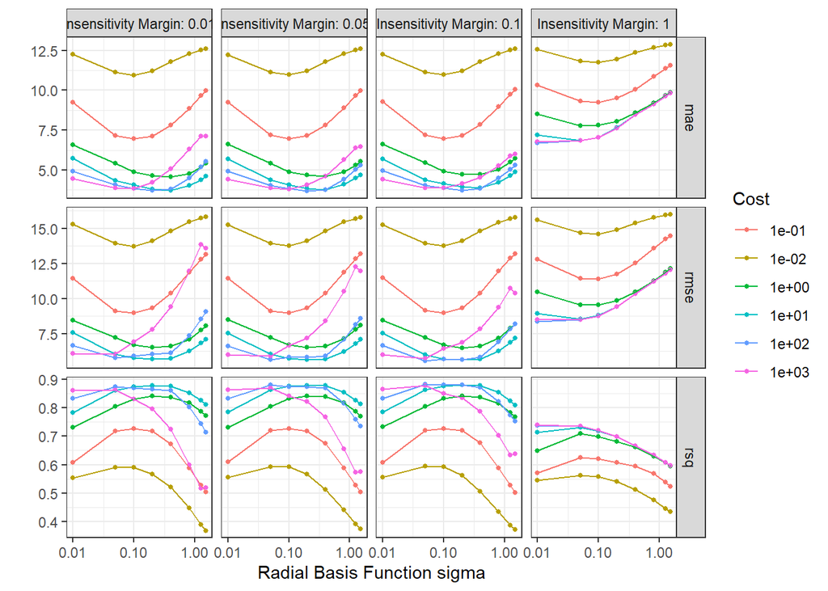

```r
svm_rbf_res %>% autoplot() + theme_bw()
```

We will identify the best tuning parameters as those that minimize the RMSE.

```r
rbf_lowest_rmse_params <- svm_rbf_res %>% select_best('rmse')

rbf_lowest_rmse_params
```

```
## # A tibble: 1 x 4
##    cost rbf_sigma margin .config
##   <dbl>     <dbl>  <dbl> <chr>
## 1   100      0.05    0.1 Preprocessor1_Model043
```

And finalize the workflow.

```r
final_svm_rbf_wflow <- svm_rbf_wflow %>%
  finalize_workflow(rbf_lowest_rmse_params)
```

As with the neural network, we will hold off comparing to the other models until later. For now, the resample results are added to the other results.

```r
all_cv_summaries <- all_cv_summaries %>%
  bind_rows(svm_rbf_res %>% collect_metrics(summarize = TRUE) %>%
              inner_join(rbf_lowest_rmse_params %>%
                           mutate(keep_these = 'yes'),
                         by = names(rbf_lowest_rmse_params)) %>%
              select(-keep_these) %>%
              mutate(wflow_id = "svm rbf"))

all_cv_results <- all_cv_results %>%
  bind_rows(svm_rbf_res %>% collect_metrics(summarize = FALSE) %>%
              inner_join(rbf_lowest_rmse_params %>%
                           mutate(keep_these = 'yes'),
                         by = names(rbf_lowest_rmse_params)) %>%
              select(-keep_these) %>%
              mutate(wflow_id = "svm rbf"))
```

#### Random forest

Random forests are extensions of recursive partitioning trees and bootstrap aggregation (bagging). Random forests are ensembles that try to overcome overfitting by averaging together many overfit models. This approach sounds counter intuitive, but we will see later in the semester how such an approach is enabled by the bootstrap. We will discuss the tuning parameters associated with random forest later in the semester. For now, focus on that as a tree based method random forest does not require preprocessing like the other models we have used. It does not have many tuning parameters. The most important one, `mtry`, is easier to interpret and we will spend some time later in the semester discussing it’s significance.

Let’s go ahead and define the model and the workflow. We will use the `ranger` package and so please download and install `ranger` before running these examples.

```r
rf_spec <- rand_forest(mtry = tune(), min_n = tune(), trees = 1000) %>%
  set_engine("ranger") %>%
  set_mode('regression')

rf_wflow <- workflow() %>%
  add_model(rf_spec) %>%
  add_formula(compressive_strength ~ .)
```

The `mtry` tuning parameter is best to define after the workflow has been defined. Again, we will discuss why that is later in the semester.

```r
rf_param <- rf_spec %>% parameters() %>% finalize(my_concrete)

rf_grid <- grid_regular(rf_param, levels = c(mtry = 7, min_n = 5))

rf_grid %>% glimpse()
```

```
## Rows: 35
## Columns: 2
## $ mtry  <int> 1, 2, 3, 5, 6, 7, 9, 1, 2, 3, 5, 6, 7, 9, 1, 2, 3, 5, 6, 7, 9, 1~
## $ min_n <int> 2, 2, 2, 2, 2, 2, 2, 11, 11, 11, 11, 11, 11, 11, 21, 21, 21, 21,~
```

The random forest is trained and assessed in the code chunk below.

```r
start_rf <- Sys.time()

set.seed(111)
rf_res <- tune_grid(
  rf_wflow,
  resamples = cv_folds,
  grid = rf_grid,
  metrics = my_metrics
)

finish_rf <- Sys.time()

finish_rf - start_rf
```

```
## Time difference of 1.87017 mins
```

The results are visualized with the `autoplot()` method below.

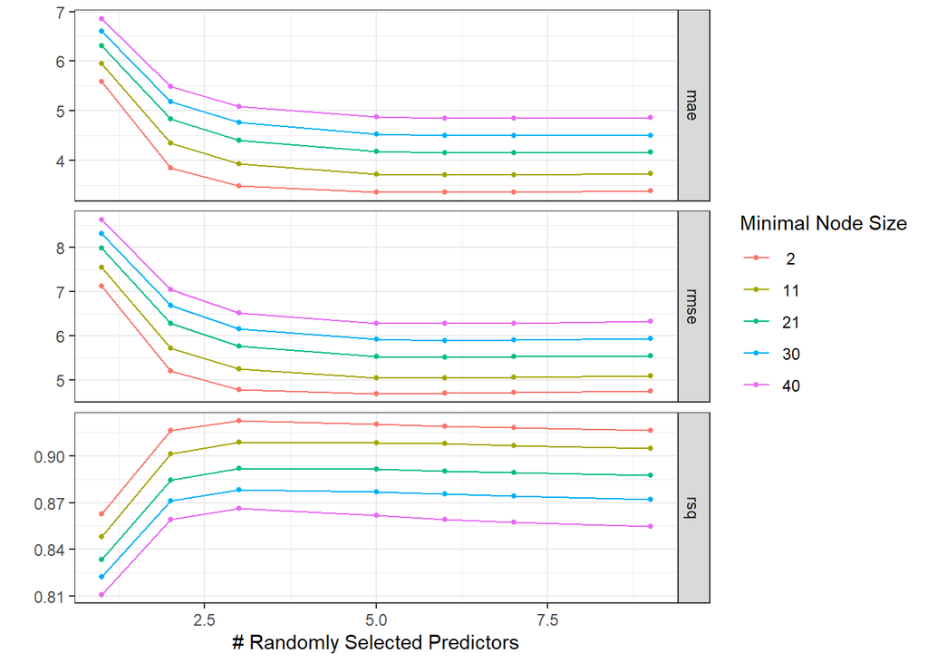

```r
rf_res %>% autoplot() + theme_bw()
```

The identified tuning parameters are selected based on minimizing RMSE below.

```r
rf_lowest_rmse_params <- rf_res %>% select_best('rmse')

rf_lowest_rmse_params
```

```
## # A tibble: 1 x 3
##    mtry min_n .config
##   <int> <int> <chr>
## 1     5     2 Preprocessor1_Model04
```

The random forest results are compiled with the other models below.

```r
all_cv_summaries <- all_cv_summaries %>%
  bind_rows(rf_res %>% collect_metrics(summarize = TRUE) %>%
              inner_join(rf_lowest_rmse_params %>%
                           mutate(keep_these = 'yes'),
                         by = names(rf_lowest_rmse_params)) %>%
              select(-keep_these) %>%
              mutate(wflow_id = "rf"))

all_cv_results <- all_cv_results %>%
  bind_rows(rf_res %>% collect_metrics(summarize = FALSE) %>%
              inner_join(rf_lowest_rmse_params %>%
                           mutate(keep_these = 'yes'),
                         by = names(rf_lowest_rmse_params)) %>%
              select(-keep_these) %>%
              mutate(wflow_id = "rf"))
```

The finalized random forest workflow is created by re-specifying the model object. This allows us to specify that the random forest should include the variable importance rankings. We will discuss how a random forest defines variable importance later in the semester. The final random forest model is the fit using the complete data set.

```r
final_rf_spec <- rand_forest(mtry = rf_lowest_rmse_params$mtry,
                              min_n = rf_lowest_rmse_params$min_n,
                              trees = 1000) %>%
  set_engine('ranger', importance = 'impurity') %>%
  set_mode('regression')

final_rf_wflow <- workflow() %>%
  add_model(final_rf_spec) %>%
  add_formula(compressive_strength ~ .)

set.seed(111)
final_rf_fit <- final_rf_wflow %>%
  fit(my_concrete)
```

#### Gradient boosted trees

Boosted trees are another class of ensemble method. Rather than averaging over many overfit models, the boosted tree sequentially combines many underfit models together. Each tree improves slightly improves the error of the previous tree in a long chain. A popular implementation of the gradient boosted tree is XGBoost. We will discuss XGBoost in depth later in the semester, but you should be aware that it has many tuning parameters. XGBoost can be quite powerful, but it takes more care and effort to properly tune compared to the random forest. We will not tune all possible parameters in this example. We will focus on the most important ones: the number of iterations (number of trees), the tree depth (which represents complexity), the learning rate (how quickly the error reduces), `mtry`, and `sample_size`. The XGBoost model is created with the `xgboost` package, so please download and install `xgboost` before running the example below.

The boosted tree model is specified in the code chunk below.

```r
xgb_spec <- boost_tree(tree_depth = tune(), learn_rate = tune(),
                       trees = tune(), mtry = tune(), sample_size = tune()) %>%
  set_engine("xgboost") %>%
  set_mode("regression")
```

The tuning parameter grid is defined below.

```r
xgb_grid <- crossing(tree_depth = c(1, 3, 6, 9),
                     learn_rate = c(0.01, 0.1, 0.3),
                     trees = c(25, 50, 100, 200, 400, 800),
                     mtry = c(3, 6),
                     sample_size = c(0.6, 0.8, 1.0))

xgb_grid %>% glimpse()
```

```
## Rows: 432
## Columns: 5
## $ tree_depth  <dbl> 1, 1, 1, 1, 1, 1, 1, 1, 1, 1, 1, 1, 1, 1, 1, 1, 1, 1, 1, 1~
## $ learn_rate  <dbl> 0.01, 0.01, 0.01, 0.01, 0.01, 0.01, 0.01, 0.01, 0.01, 0.01~
## $ trees       <dbl> 25, 25, 25, 25, 25, 25, 50, 50, 50, 50, 50, 50, 100, 100, ~
## $ mtry        <dbl> 3, 3, 3, 6, 6, 6, 3, 3, 3, 6, 6, 6, 3, 3, 3, 6, 6, 6, 3, 3~
## $ sample_size <dbl> 0.6, 0.8, 1.0, 0.6, 0.8, 1.0, 0.6, 0.8, 1.0, 0.6, 0.8, 1.0~
```

As a tree-based method XGBoost does not require much preprocessing. Thus, the workflow defined below does not require the standardized recipe.

```r
xgb_wflow <- workflow() %>%
  add_model(xgb_spec) %>%
  add_formula(compressive_strength ~ .)
```

The XGBoost model is trained and assessed in the code chunk below.

```r
start_xgb <- Sys.time()

set.seed(111)
xgb_res <- tune_grid(
  xgb_wflow,
  resamples = cv_folds,
  grid = xgb_grid,
  metrics = my_metrics
)

finish_xgb <- Sys.time()

finish_xgb - start_xgb
```

```
## Time difference of 4.830693 mins
```

We have five tuning parameters, and so we will ignore the confidence intervals on the average performance just to simplify the figures. The resampling averaged RMSE is visualized below. The y-axis scales are different across the vertical facets. The figure below reveals there seems to be a relationship between the the learning rate and the number of trees. We will learn why that is later in the semester.

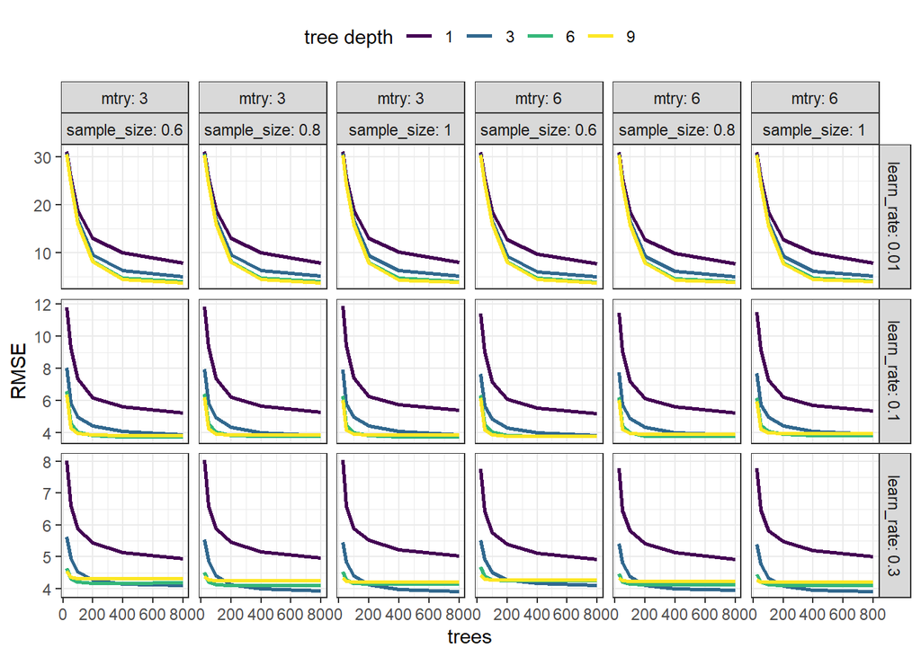

```r
xgb_res %>% collect_metrics() %>%
  filter(.metric == 'rmse') %>%
  ggplot(mapping = aes(x = trees, y = mean)) +
  geom_line(mapping = aes(color = as.factor(tree_depth),
                          group = interaction(mtry, tree_depth,
                                              learn_rate, sample_size)),
            size = 1.) +
  facet_grid(learn_rate ~ mtry + sample_size, labeller = "label_both",
             scales = "free_y") +
  scale_color_viridis_d("tree depth") +
  labs(y = 'RMSE') +
  theme_bw() +
  theme(legend.position = "top")
```

Next, let’s look at the R-squared averaged results.

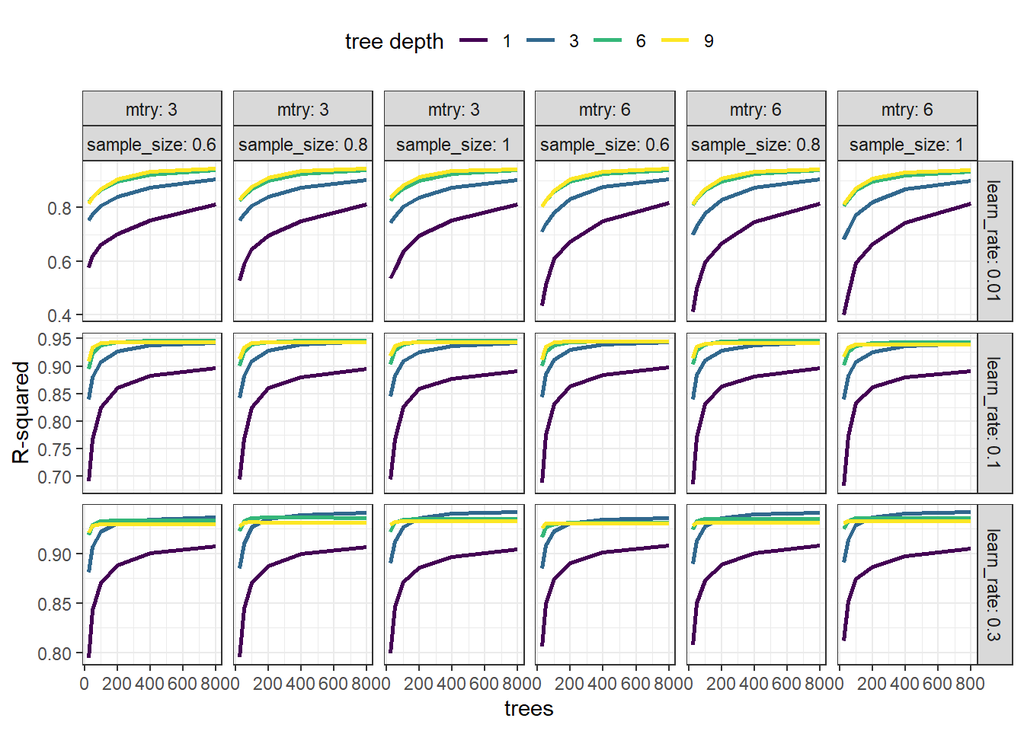

```r
xgb_res %>% collect_metrics() %>%
  filter(.metric == 'rsq') %>%
  ggplot(mapping = aes(x = trees, y = mean)) +
  geom_line(mapping = aes(color = as.factor(tree_depth),
                          group = interaction(mtry, tree_depth,
                                              learn_rate, sample_size)),
            size = 1.) +
  facet_grid(learn_rate ~ mtry + sample_size, labeller = "label_both",
             scales = "free_y") +
  scale_color_viridis_d("tree depth") +
  labs(y = "R-squared") +
  theme_bw() +
  theme(legend.position = "top")
```

Let’s identify the tuning parameters as those which minimize the RMSE.

```r
xgb_lowest_rmse_params <- xgb_res %>% select_best('rmse')

xgb_lowest_rmse_params
```

```
## # A tibble: 1 x 6
##    mtry trees tree_depth learn_rate sample_size .config
##   <dbl> <dbl>      <dbl>      <dbl>       <dbl> <chr>
## 1     3   800          6        0.1           1 Preprocessor1_Model270
```

The finalized XGBoost workflow is defined, and the final fit on the entire data set is executed below.

```r
final_xgb_wflow <- xgb_wflow %>%
  finalize_workflow(xgb_lowest_rmse_params)

set.seed(111)
final_xgb_fit <- final_xgb_wflow %>% fit(my_concrete)
```

The XGBoost resampling results are compiled with the other model results below.

```r
all_cv_summaries <- all_cv_summaries %>%
  bind_rows(xgb_res %>% collect_metrics(summarize = TRUE) %>%
              inner_join(xgb_lowest_rmse_params %>%
                           mutate(keep_these = 'yes'),
                         by = names(xgb_lowest_rmse_params)) %>%
              select(-keep_these) %>%
              mutate(wflow_id = "xgb"))

all_cv_results <- all_cv_results %>%
  bind_rows(xgb_res %>% collect_metrics(summarize = FALSE) %>%
              inner_join(xgb_lowest_rmse_params %>%
                           mutate(keep_these = 'yes'),
                         by = names(xgb_lowest_rmse_params)) %>%
              select(-keep_these) %>%
              mutate(wflow_id = "xgb"))
```

### Model comparison

With all of the models tuned and assessed with resampling, let’s compare the performance metrics and identify the best overall models. We will focus on the overall resampling averaged results to simplify the figure. The model names are ordered such that the model with the lowest averaged RMSE is at the top of the figure and the model with the highest averaged RMSE is at the bottom. As we can see below, the XGBoost model is the best performing model in terms of MAE, RMSE, and R-squared. The random forest and tuned neural network have comparable performance, but XGBoost outperforms both.

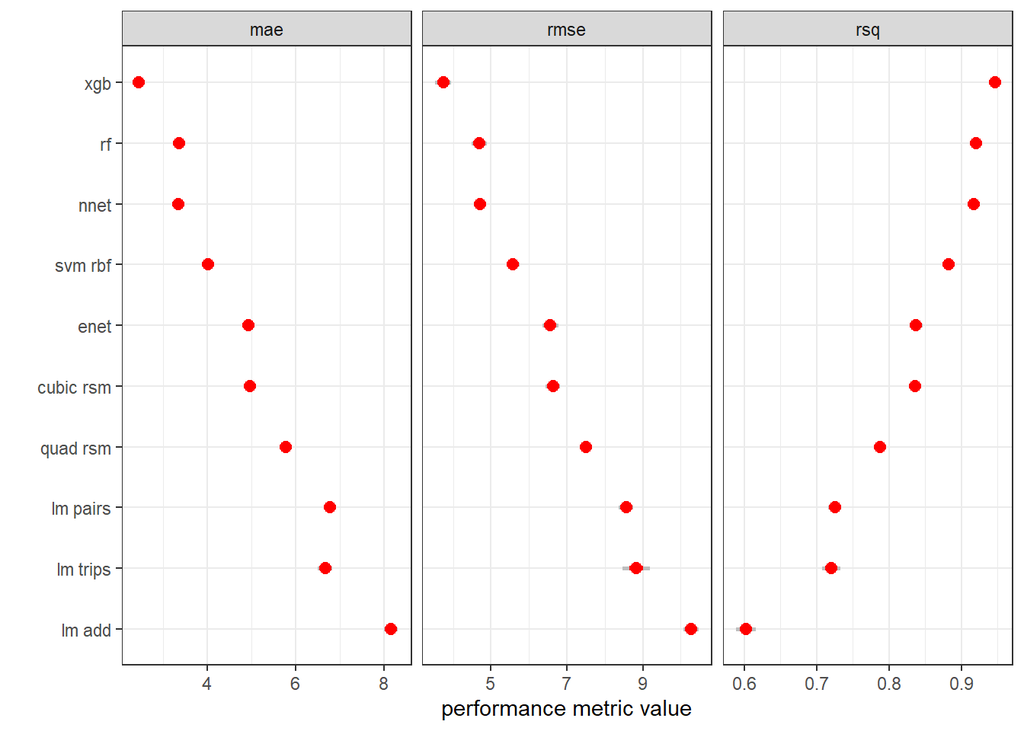

```r
all_cv_summaries %>%
  mutate(wflow_id = forcats::fct_reorder(wflow_id, mean, min)) %>%
  ggplot(mapping = aes(x = wflow_id)) +
  geom_linerange(mapping = aes(ymin = mean - 2*std_err,
                               ymax = mean + 2*std_err,
                               group = interaction(.metric, wflow_id)),
                 color = 'grey', size = 1.) +
  geom_linerange(mapping = aes(ymin = mean - 1*std_err,
                               ymax = mean + 1*std_err,
                               group = interaction(.metric, wflow_id)),
                 color = 'red', size = 1.2) +
  geom_point(mapping = aes(y = mean),
             color = 'red', size = 2.5) +
  coord_flip() +
  facet_wrap(~.metric, scales = "free_x") +
  labs(y = "performance metric value", x ="") +
  theme_bw()
```

Next, let’s look at the correlation between the models. The figure below shows the correlation coefficient between the R-squared performance metric values across all resamples. The XGBoost and random forest models are highly correlated. Interestingly, the tree-based methods are not all that correlated with the neural network. This suggests that data points inaccurately predicted by the neural network are not always the same as those inaccurately predicted by the tree-based methods.

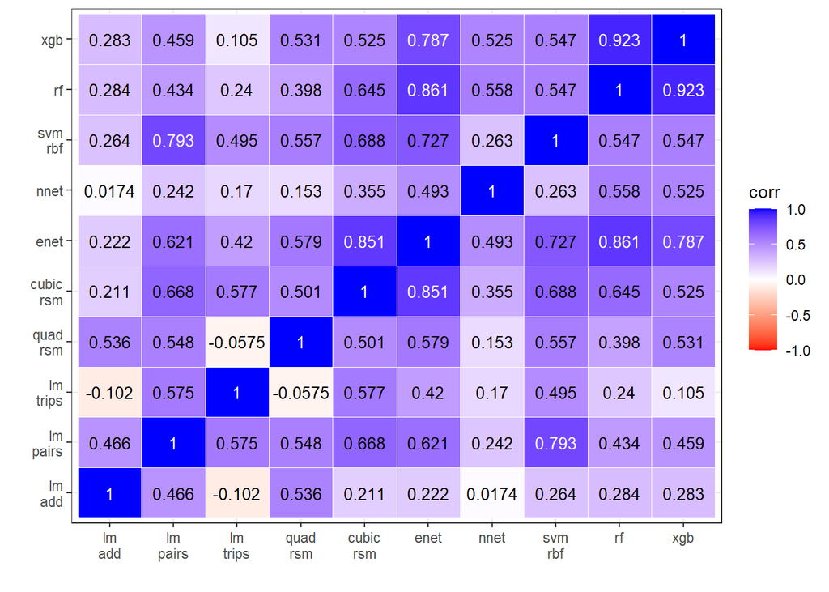

```r
all_cv_results %>%
  mutate(wflow_id = stringr::str_replace(wflow_id, " ", "\n")) %>%
  filter(.metric == 'rsq') %>%
  select(wflow_id, .estimate, id, id2) %>%
  pivot_wider(id_cols = c("id", "id2"),
              names_from = 'wflow_id', values_from = '.estimate') %>%
  select(-id, -id2) %>%
  corrr::correlate(quiet = TRUE, diagonal = 1) %>%
  corrr::stretch() %>%
  mutate(x = factor(x,
                    levels = c("lm\nadd", "lm\npairs", "lm\ntrips",
                                      "quad\nrsm", "cubic\nrsm", "enet",
                               "nnet", "svm\nrbf", "rf", "xgb")),
         y = factor(y,
                    levels = c("lm\nadd", "lm\npairs", "lm\ntrips",
                                      "quad\nrsm", "cubic\nrsm", "enet",
                               "nnet", "svm\nrbf", "rf", "xgb"))) %>%
  ggplot(mapping = aes(x = x, y = y)) +
  geom_tile(mapping = aes(fill = r),
            color = 'white') +
  geom_text(mapping = aes(label = signif(r, 3),
                          color = abs(r) > 0.75),
            size = 3.5) +
  scale_fill_gradient2('corr',
                       low = 'red', mid = 'white', high = 'blue',
                       midpoint = 0,
                       limits = c(-1, 1)) +
  scale_color_manual(guide = 'none',
                     values = c("TRUE" = 'white',
                                "FALSE" = 'black')) +
  labs(x='', y='') +
  theme_bw()
```

### Variable importances

Now that we know which models are best, let’s examine which inputs are most important. We will focus on the top three models, XGBoost, random forest, and the neural network. The variable importances are extracted with the `vip` package, which should be downloaded and installed with `tidymodels`. Please double check before running the code chunks below.

```r
library(vip)
```

The three variable importance plots are arranged side-by-side in the graphic below. The exact values of th importances are not necessarily what we want to focus on right now. Instead, we are primarily interested in the ordering. Regardless of the model, the variable with the highest absolute importance value is considered the most important input. All three models agree that `age` is the most important input. Also, all three models agree that `cement` is the second most important input. The tree-based methods agree that `water` is the third most important input, but the neural network considers `blast_furnace_slag` to be the third most important input. Please note that the variable importance method used for the neural network model considers the magnitude and sign of the importance. That is why the `water` variable is listed at the bottom of the NNET plot.

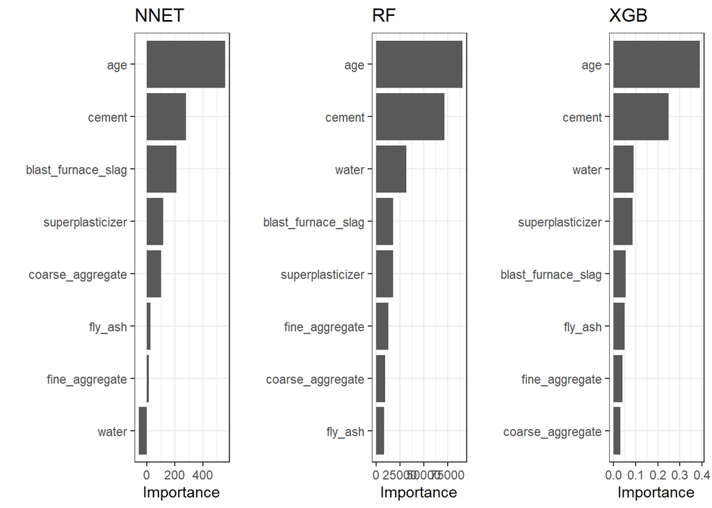

```r
nnet_vip <- final_nnet_fit %>%
  extract_fit_parsnip() %>%
  pluck("fit") %>%
  vip(type='olden') +
  labs(title = "NNET") +
  theme_bw()

rf_vip <- final_rf_fit %>%
  extract_fit_parsnip() %>%
  pluck("fit") %>%
  vip() +
  labs(title = "RF") +
  theme_bw()

xgb_vip <- final_xgb_fit %>%
  extract_fit_parsnip() %>%
  pluck("fit") %>%
  vip() +
  labs(title = "XGB") +
  theme_bw()

grid.arrange(nnet_vip, rf_vip, xgb_vip, ncol = 3)
```

I like to examine the variable importances associated with several top performing models. I am mainly looking for consistency in the rankings. For this application, it is nice to see that the top two inputs are agreed upon by the best models.

### Predictive trends

Let’s make predictions with our top three models to help provide additional context to the variable importance rankings. Afterall, we know that the XGBoost model is considered the best. The XGBoost variable importance rankings are slightly different from the random forest model, but the overall rankings are still similar. The neural network and random forest rankings however are different, except for the top two as described above. Let’s see if predictions can help us understand why.

We will examine the predictive trends associated with the top three ranked inputs according to the XGBoost model. The rest of the inputs will be set equal to their training set median values. The prediction grid is created in the code chunk below.

```r
viz_grid_a <- crossing(age = floor(seq(min(my_concrete$age),
                                       max(my_concrete$age),
                                       length.out = 25)),
                       cement = seq(min(my_concrete$cement),
                                    max(my_concrete$cement),
                                    length.out = 11),
                       water = as.numeric(quantile(my_concrete$water)),
                       superplasticizer = median(my_concrete$superplasticizer),
                       blast_furnace_slag = median(my_concrete$blast_furnace_slag),
                       fly_ash = median(my_concrete$fly_ash),
                       fine_aggregate = median(my_concrete$fine_aggregate),
                       coarse_aggregate = median(my_concrete$coarse_aggregate))

viz_grid_a %>% glimpse()
```

```
## Rows: 1,375
## Columns: 8
## $ age                <dbl> 1, 1, 1, 1, 1, 1, 1, 1, 1, 1, 1, 1, 1, 1, 1, 1, 1, ~
## $ cement             <dbl> 102.0, 102.0, 102.0, 102.0, 102.0, 145.8, 145.8, 14~
## $ water              <dbl> 121.800, 167.875, 185.700, 192.900, 247.000, 121.80~
## $ superplasticizer   <dbl> 6, 6, 6, 6, 6, 6, 6, 6, 6, 6, 6, 6, 6, 6, 6, 6, 6, ~
## $ blast_furnace_slag <dbl> 20, 20, 20, 20, 20, 20, 20, 20, 20, 20, 20, 20, 20,~
## $ fly_ash            <dbl> 0, 0, 0, 0, 0, 0, 0, 0, 0, 0, 0, 0, 0, 0, 0, 0, 0, ~
## $ fine_aggregate     <dbl> 780, 780, 780, 780, 780, 780, 780, 780, 780, 780, 7~
## $ coarse_aggregate   <dbl> 968, 968, 968, 968, 968, 968, 968, 968, 968, 968, 9~
```

Notice that the input values were specified in the raw ranges. Any required preprocessing, such as standardizing, will be appropriately applied by the defined workflow for a given model. This is one of the major benefits of using a workflow which includes the preprocessing **and** the model fit.

Let’s go ahead and make predictions with all three models and compile the results to support visualization. The graphic below makes it clear how the neural network is different from the tree-based methods. The random forest and XGBoost predictive trends are relatively similar. The neural network yields more “fanned out” predictions for this particular example.

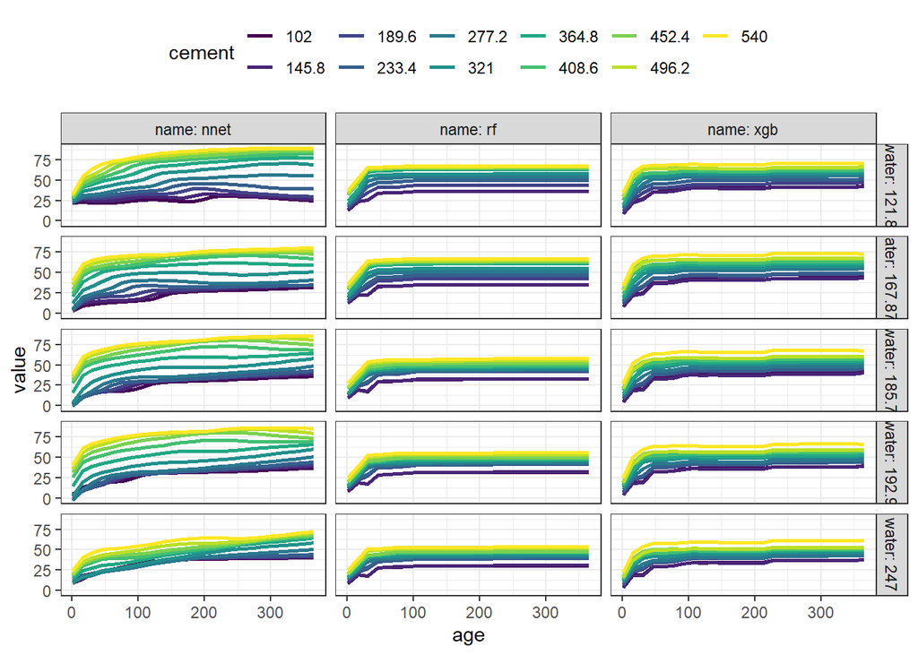

```r
predict(final_nnet_fit, new_data = viz_grid_a) %>%
  purrr::set_names(c("nnet")) %>%
  bind_cols(predict(final_rf_fit, new_data = viz_grid_a) %>%
              purrr::set_names(c("rf"))) %>%
  bind_cols(predict(final_xgb_fit, new_data = viz_grid_a) %>%
              purrr::set_names(c("xgb"))) %>%
  bind_cols(viz_grid_a) %>%
  pivot_longer(c("nnet", "rf", "xgb")) %>%
  ggplot(mapping = aes(x = age, y = value)) +
  geom_line(mapping = aes(color = as.factor(cement),
                          group = interaction(cement, water, name)),
            size = 1.) +
  facet_grid(water ~ name, labeller = "label_both") +
  scale_color_viridis_d("cement") +
  theme_bw() +
  theme(legend.position = "top") +
  guides(color = guide_legend(nrow = 2))
```

Next, let’s create a grid which focuses on the trends with respect to `cement`.

```r
viz_grid_b <- crossing(age = c(1, 7, 14, 28, 56, 90, 180),
                       cement = seq(min(my_concrete$cement),
                                    max(my_concrete$cement),
                                    length.out = 31),
                       water = as.numeric(quantile(my_concrete$water)),
                       superplasticizer = median(my_concrete$superplasticizer),
                       blast_furnace_slag = median(my_concrete$blast_furnace_slag),
                       fly_ash = median(my_concrete$fly_ash),
                       fine_aggregate = median(my_concrete$fine_aggregate),
                       coarse_aggregate = median(my_concrete$coarse_aggregate))

viz_grid_b %>% glimpse()
```

```
## Rows: 1,085
## Columns: 8
## $ age                <dbl> 1, 1, 1, 1, 1, 1, 1, 1, 1, 1, 1, 1, 1, 1, 1, 1, 1, ~
## $ cement             <dbl> 102.0, 102.0, 102.0, 102.0, 102.0, 116.6, 116.6, 11~
## $ water              <dbl> 121.800, 167.875, 185.700, 192.900, 247.000, 121.80~
## $ superplasticizer   <dbl> 6, 6, 6, 6, 6, 6, 6, 6, 6, 6, 6, 6, 6, 6, 6, 6, 6, ~
## $ blast_furnace_slag <dbl> 20, 20, 20, 20, 20, 20, 20, 20, 20, 20, 20, 20, 20,~
## $ fly_ash            <dbl> 0, 0, 0, 0, 0, 0, 0, 0, 0, 0, 0, 0, 0, 0, 0, 0, 0, ~
## $ fine_aggregate     <dbl> 780, 780, 780, 780, 780, 780, 780, 780, 780, 780, 7~
## $ coarse_aggregate   <dbl> 968, 968, 968, 968, 968, 968, 968, 968, 968, 968, 9~
```

The predictions from the top three models are visualized below. The x-axis corresponds to `cement` while the line color denotes the `age`. The tree-based methods yield trends with respect to that appear more linear compared to the neural network trends. The tree-based predictive trends shown below appear consistent with the visual trends identified in the EDA.

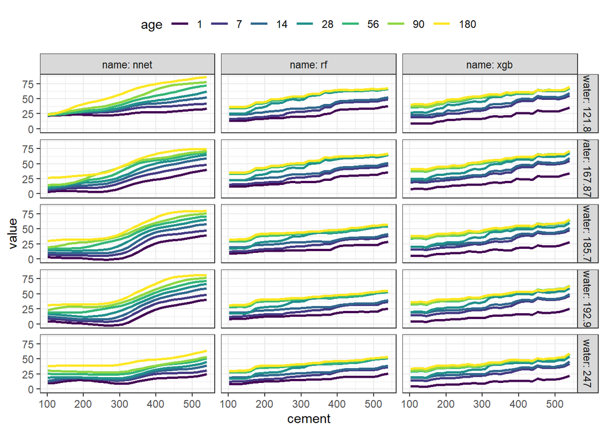

```r
predict(final_nnet_fit, new_data = viz_grid_b) %>%
  purrr::set_names(c("nnet")) %>%
  bind_cols(predict(final_rf_fit, new_data = viz_grid_b) %>%
              purrr::set_names(c("rf"))) %>%
  bind_cols(predict(final_xgb_fit, new_data = viz_grid_b) %>%
              purrr::set_names(c("xgb"))) %>%
  bind_cols(viz_grid_b) %>%
  pivot_longer(c("nnet", "rf", "xgb")) %>%
  ggplot(mapping = aes(x = cement, y = value)) +
  geom_line(mapping = aes(color = as.factor(age),
                          group = interaction(age, water, name)),
            size = 1.) +
  facet_grid(water ~ name, labeller = "label_both") +
  scale_color_viridis_d("age") +
  theme_bw() +
  theme(legend.position = "top") +
  guides(color = guide_legend(nrow = 1))
```

## Conclusion

This report demonstrated a complete predictive modeling application starting with data import, preparation, cleaning, and exploration. We trained and assessed with resampling multiple linear and non-linear methods. We saw how to tune models and select the best based on several performance metrics. We examined the variable importance rankings and used predictions to help provide further context about the model behavior.

The specific set of performance metrics used and discussion in this report are specific to regression problems. We will discuss the theoretical details associated with the models later in the semester. This report was focused on the proper approach for applying machine learning methods to a realistic application.

This concludes the report. The parallel backend is stopped in the code chunk below.

```r
if(parallel::detectCores(logical=FALSE) > 3){
  stopCluster(cl)
}
```